# Exercise 5: Approximate Bayesian Computation (ABC)

Eawag Summer School in Environmental Systems Analysis (back to overview)

**Objectives**

- Understand when to use Approximate Bayesian Computation (ABC) and when not.
- Understand the fundamental difference between ABC and likelihood-based inference.
- Understand why and how to use summary statistics in ABC.

In this exercise, we run the Simulated Annealing ABC (SABC), for a Bayesian inference of the parameter of the model “survival”, with a flat prior. Note, in practice, we would not want to use an ABC algorithm for this problem. Why?

# Define prior and a function to sample from the model

For ABC, we need to define the prior density and a function that generates random outputs from our model $p(y|\theta)$. That means we are sampling from the likelihood. Note however, that we do not need a function which evaluates the density of the likelihood.

## R

We use the R package [`EasyABC`](https://cran.r-project.org/web/packages/EasyABC/index.html), which contains multiple sampling schemes for Approximate Bayes Computations.

```r
library(EasyABC)
library(FME)  # for adaptive Metropolis algorithm
```

As a next step, let’s read the data that we observed in the form of death counts per observation interval, and which we try to explain by the model survival. The experiment was started with `N=30` individuals.

```r
obs <- read.table("../../data/model_survival.csv", header=T)
head(obs)
```

```
##   time deaths
## 1    1      2
## 2    2      7
## 3    3      4
## 4    4      5
## 5    5      1
```

For ABC, we always need a function that evaluates the prior density, a function that samples from the prior, and a function that generates random model outputs (our model). The functions that we need are defined in the following:

```r
d.prior <- function(par) dunif(par, min=0.01, max=0.6) # density of prior
r.prior <- function() runif(1, min=0.01, max=0.6)      # sample from prior

## produce model output
survival.sampler <- function(par, t = obs$time, N = 30){
    if(par<0) return(rep(0,length(t)))       # return "no deaths" if par is negative:
    S <- exp(-par*c(0,t))                    # and add zero "at time-point infinity"
    S <- c(S,0)
    p <- -diff(S)                            # probabilities to die within observation windows
    y <- rmultinom(1, N, p)[-(length(t)+1) ] # sample from multinomial distribution
                                             # (assume that there are N individuals
                                             #  at the beginning of the experiment)
    return(y)
}
```

## Julia

We use the Julia package [`SimulatedAnnealingABC.jl`](https://github.com/Eawag-SIAM/SimulatedAnnealingABC.jl), which implements the SABC algorithm. We also need packages for distributions and data handling.

```julia
using SimulatedAnnealingABC
using Distributions
using CSV
using DataFrames
```

Next, we load the observed death counts. The experiment started with **N=30** individuals.

```julia
obs = CSV.read("../../data/model_survival.csv", DataFrame);
```

For ABC, we need a prior distribution, a function to sample from it, and a model function that generates random outputs.

```julia
# Define the prior distribution and functions to evaluate its density and to sample from it
prior = Uniform(0.01, 0.6)
```

```
## Uniform{Float64}(a=0.01, b=0.6)
```

```julia
d_prior(x) = pdf(prior, x)
```

```
## d_prior (generic function with 1 method)
```

```julia
r_prior() = rand(prior)
```

```
## r_prior (generic function with 1 method)
```

```julia
# Model function that generates a random output
function survival_sampler(λ; N=30, t=obs.time)
    # S is a vector whose first component is 1 and last is 0,
    # because the probability to be alive at time t=0 is 1,
    # and the probability to be alive at time t=infinity is 0
    S = exp.(-λ .* t)
    S = [1; S; 0]
    p = -diff(S)

    y = rand(Multinomial(N, p))[1:(end-1)]
    return y
end
```

```
## survival_sampler (generic function with 1 method)
```

# 1. ABC without summary statistics

For ABC we need a distance measure to compare the model output to the observations, in order to judge the plausibility of the parameters that generated this model output. Here we do not apply summary statistics, we compare the model output and the observations directly.

## R

Use the use the sum of the absolute distances a distance function.

```r
f.dist <- function(par) {
    sum(abs(survival.sampler(par) - obs$deaths))
}
```

Now we can run the SABC using `f.dist`:

```r
SABC.res <- SABC(
  r.model       = f.dist,  # function that directly returns scalar
                                        # distance between a random model output and data
  r.prior       = r.prior, # sampler from prior
  d.prior       = d.prior, # density evaluator of prior
  n.sample      = 2000,
  eps.init      = 20,
  iter.max      = 300000,
  v             = 1.2,
  beta          = 0.8
)
```

## Julia

We define a distance function that calculates the sum of absolute differences between the model output and the observations.

```julia
f_dist(par, obs) = Float64(sum((abs.(survival_sampler(par) .- obs.deaths))))
```

```
## f_dist (generic function with 1 method)
```

Now, we can run the SABC algorithm using this distance function.

```julia
sabc_res = sabc(f_dist, prior,  obs;
                n_simulation = 300_000, # Maximum number function evaluations
                n_particles = 2000)     # Number of samples to generate
```

```
## Approximate posterior sample with 2000 particles:
##   - algorithm: :single_eps
##   - simulations used: 300000
##   - number of population updates: 149
##   - average transformed distance: 0.00491
##   - ϵ: [0.0008191]
##   - number of population resamplings: 3
##   - acceptance rate: 0.05308
## The sample can be accessed with the field `population`.
## The history of ϵ can be accessed with the field `state.ϵ_history`.
## The history of ρ can be accessed with the field `state.ρ_history`.
## The history of u can be accessed with the field `state.u_history`.
```

# 2. ABC with semi-automatically generated summary statistics

Finding good (ideally sufficient) summary statistics is no always easy. Fearnhead and Prangle (2012) proposes a semi-automatic way to generate summary statistics.

## R

The `SABC` function can derive summary statistics semi-automatically. “Semi-automatically” means that the user needs to provide the function `f.summarystats` that transforms model outputs. The algorithm then employs a linear regression from the transformed outputs to the model parameters to define the summary statistics (Fearnhead and Prangle (2012)).

For this exercise, use the identity `f.summarystats(y)=y`. This means that we use a standard linear regression to estimate the parameters from the output and use these estimators as summary.

```r
f.summarystats <- function(y) {y}

SABC.SS.res <- SABC(
  r.model       = survival.sampler, # function that returns model output
  r.prior       = r.prior,          # sampler from prior
  d.prior       = d.prior,          # density evaluator of prior
  n.sample      = 2000,
  eps.init      = 20,
  iter.max      = 300000,
  summarystats  = TRUE,
  y             = obs$deaths,
  f.summarystats= f.summarystats,
  v             = 1.2,
  beta          = 0.8
)
```

## Julia

This method is not yet implemented in `SimulatedAnnealingABC.jl`.

# 3. Use sufficient summary statistics

This simple model has a set of two sufficient statistics (even though there is just one parameter!). You can try to derive them!

## R

Definition of the summery statistics and the distance function:

```r
ss <- function(y){
    c(sum(y),                   # statistic 1
      sum(y*seq(1,length(y))))  # statistic 2
}

f.dist <- function(par) {
    sum(abs(ss(survival.sampler(par)) - ss(obs$deaths)))
}


SABC.suff.res <- SABC(
  r.model       = f.dist,  # function that directly returns scalar
                           # distance between a random model output and data
  r.prior       = r.prior, # sampler from prior
  d.prior       = d.prior, # density evaluator of prior
  n.sample      = 2000,
  eps.init      = 20,
  iter.max      = 300000,
  v             = 1.2,
  beta          = 0.8
)
```

## Julia

Definition of the summery statistics and the distance function:

```julia
# Function to calculate sufficient statistics
ss(y) = (sum(y),
         sum(y .* (1:length(y)))
         )
```

```
## ss (generic function with 1 method)
```

```julia
# Distance function based on sufficient statistics
f_dist_suff(par, obs) = Float64(sum(abs.(ss(survival_sampler(par)) .- ss(obs.deaths))))
```

```
## f_dist_suff (generic function with 1 method)
```

```julia
sabc_suff_res = sabc(f_dist_suff, prior, obs;
                     n_simulation = 300_000, # Maximum number function evaluations
                     n_particles = 2000)     # Number of samples to generate
```

```
## Approximate posterior sample with 2000 particles:
##   - algorithm: :single_eps
##   - simulations used: 300000
##   - number of population updates: 149
##   - average transformed distance: 0.001281
##   - ϵ: [0.000138]
##   - number of population resamplings: 4
##   - acceptance rate: 0.0552
## The sample can be accessed with the field `population`.
## The history of ϵ can be accessed with the field `state.ϵ_history`.
## The history of ρ can be accessed with the field `state.ρ_history`.
## The history of u can be accessed with the field `state.u_history`.
```

# 4. Compare the previously generated posterior samples to a sample from the true posterior

For this model we do not need to use ABC (and should not!) because we can evaluate the density of the likelihood function, hence we can sample from the posterior with normal MCMC methods. This allows us to compare the two samples generated in the previous tasks to a sample of the “true posterior”.

## R

To generate a sample of the true posterior, we first define the posterior function (see Monday excerises):

```r
logposterior <- function(y, N=30, t, par){
    log.prior <- log(d.prior(par))
    if(!is.finite(log.prior)) return(-Inf)

    ## Calculate survival probabilities at measurement points
    ## and add zero "at time-point infinity":
    S <- exp(-par*c(0,t))
    S <- c(S,0)
    ## Calculate probabilities to die within observation windows:
    p <- -diff(S)
    ## Add number of survivors at the end of the experiment:
    y <- c(y, N-sum(y))
    ## Calculate log-likelihood of multinomial distribution at point y:
    LL <- dmultinom(y, prob=p, log=TRUE)

    return(LL + log.prior)
}
```

In the following, we use an adaptive Metropolis algorithm to generate a sample from the true posterior:

```r
par.start <- c("lambda"=0.5)
jump.cov  <- 0.01
ntrydr     <- 3       # number of trials for Delayed Rejection
acc.rate   <- 0.23    # Desired acceptance rate for the Robust Adaptive Metropolis
iterations <- 10000   # length of the chain

## Run the Adaptive Metropolis Algorithm with Delayed Rejection:
obj.funct <- function(par, y, t){ -2*logposterior(y, N=30, t, par) }

AMDR <- modMCMC(
    f         = obj.funct,
    p         = par.start,
    jump      = jump.cov,
    niter     = 10000,
    updatecov = 10,
    covscale  = 2.4^2,
    ntrydr    = ntrydr,
    y = obs$deaths,
    t = obs$time
)
```

```
## number of accepted runs: 9557 out of 10000 (95.57%)
```

```r
## Cut off burn-in and adaptation phase:
AMDR.chain  <- AMDR$pars[-(1:1000),]
```

Let us now compare the posterior samples generated with ABC with and without summary statistics, and the sample of the true posterior. In the first figure below, you can see that not using summary statistics can lead to slow convergence: many proposals will be rejected since in high dimensions it is very unlikely to match the data with sufficient accuracy. However, the sample seems to converge to the true distribution. The second figure shows that summary statistics speed up convergence, but, since there is no single sufficient statistic, this comes at the cost of a loss of information, which leads to biased results. The third figure shows that using two sufficient statistics leads to a fast convergence to an unbiased result.

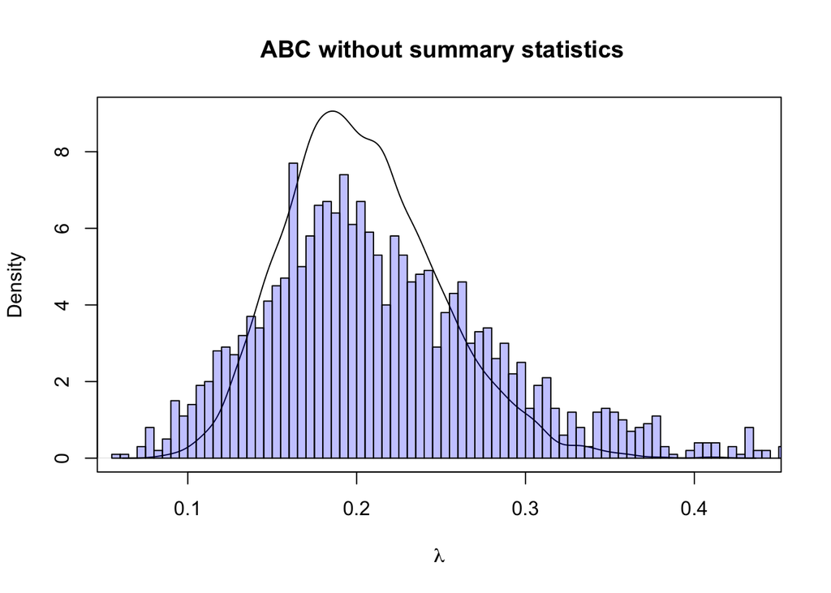

True posterior (line) and sample generated via ABC **without** summary statistics (histogram).

```r
plot(density(AMDR.chain), xlab=expression(lambda), main=" ABC without summary statistics")
hist(SABC.res$E[,1], add=TRUE, probability=TRUE,
     breaks=100, col=rgb(0,0,1,1/4))
```

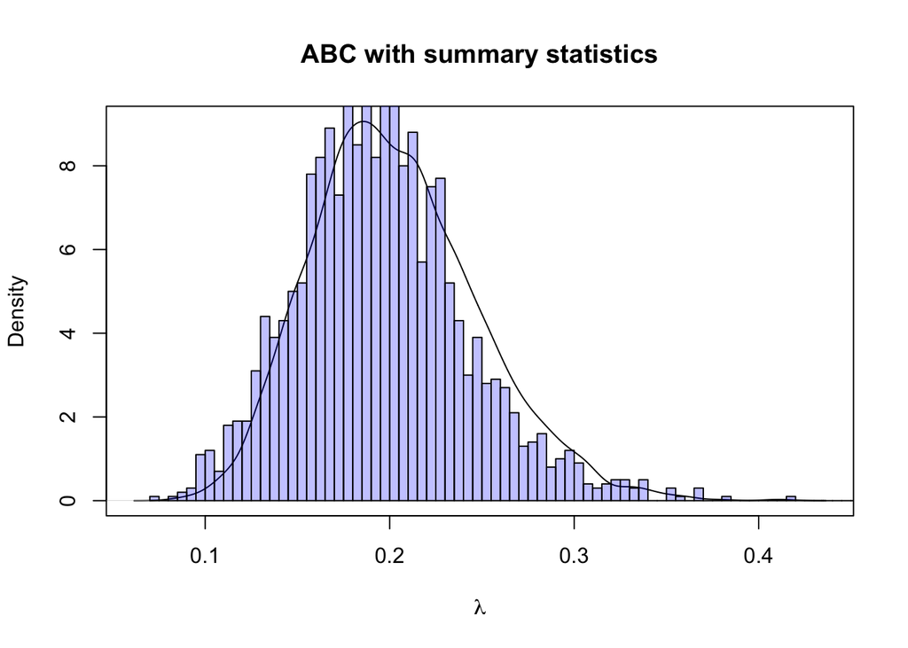

True posterior (line) and sample generated via ABC **with** summary statistics (histogram).

```r
plot(density(AMDR.chain), xlab=expression(lambda), main="ABC with summary statistics")
hist(SABC.SS.res$E[,1], add=TRUE, probability=TRUE,
     breaks=100, col=rgb(0,0,1,1/4))
```

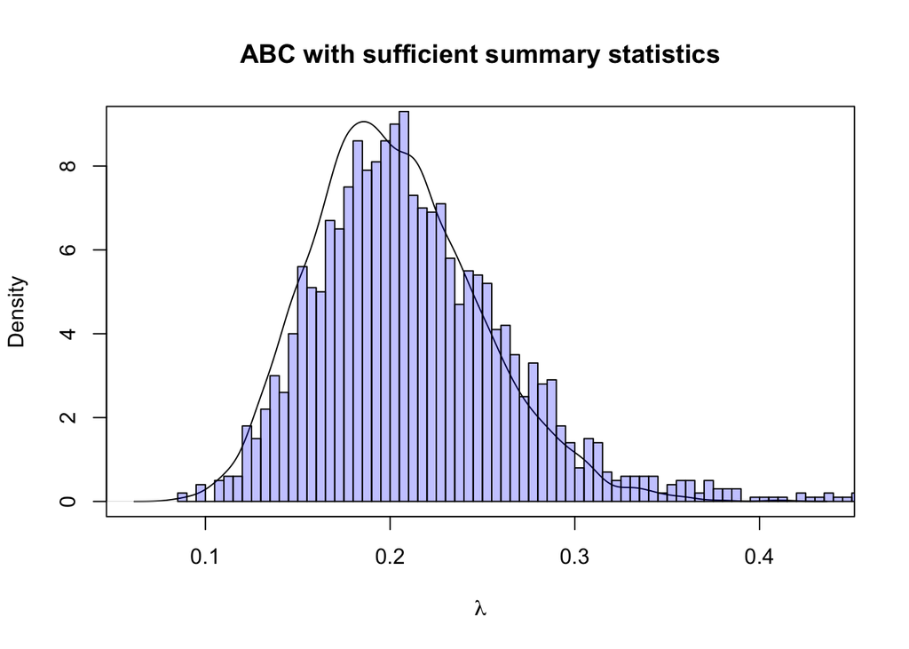

True posterior (line) and sample generated via ABC **with sufficient** summary statistics (histogram).

```r
plot(density(AMDR.chain), xlab=expression(lambda), main="ABC with sufficient summary statistics")
hist(SABC.suff.res$E[,1], add=TRUE, probability=TRUE,
     breaks=100, col=rgb(0,0,1,1/4))
```

## Julia

To get a sample from the “true” posterior, we first define the log-posterior function.

```julia
using AdaptiveMCMC
using MCMCChains
using Plots
using StatsPlots

function loglikelihood_survival(N::Int, t, y, λ)
    S = exp.(-λ .* t)
    S = [1; S; 0]
    p = -diff(S)
    ## Add number of survivors at the end of the experiment:
    y = [y; N-sum(y)]

    logpdf(Multinomial(N, p), y)
end
```

```
## loglikelihood_survival (generic function with 2 methods)
```

```julia
function logposterior(par)
    ll = logpdf(prior, par[1])
    if isfinite(ll)
        ll = ll + loglikelihood_survival(30, obs.time, obs.deaths, par[1])
    end
    return ll
end
```

```
## logposterior (generic function with 1 method)
```

Then we use the `AdaptiveMCMC` package to run a MCMC sampler to get a reference solution.

```julia
mcmc_res = adaptive_rwm([0.3], logposterior,
                        10_000;
                   algorithm = :ram,
                   b = 1000,   # length of burn-in
                   );
```

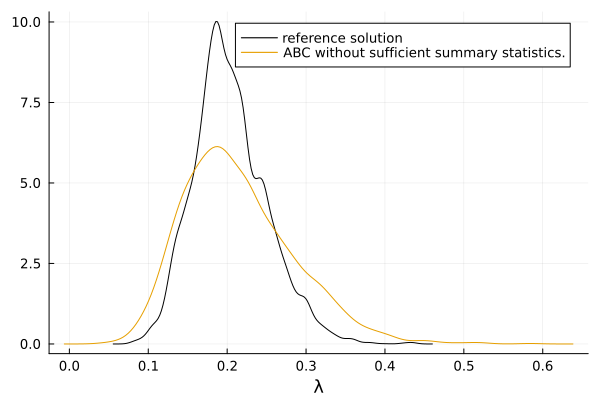

```julia
StatsPlots.density(mcmc_res.X', label = "reference solution", xlab="λ");
StatsPlots.density!(sabc_res.population, label = "ABC without sufficient summary statistics.")
```

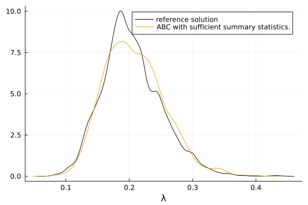

```julia
StatsPlots.density(mcmc_res.X', label = "reference solution", xlab="λ");
StatsPlots.density!(sabc_suff_res.population, label = "ABC with sufficient summary statistics.")
```